# Histograms and Z-Scores

your name here

2026-09-02

## Part 1: Load packages and import data

In the following code chunk, do the following:

1. Load the package called `tidyverse`
2. Load the package called `ggplot2`
3. Import `sample_heights.csv` and assign it to the variable `heights_table`
4. Use the `head()` function to take a peak at your data table

```r
library(tidyverse)
```

```r
library(ggplot2)

heights_table <- read_csv("sample_heights.csv")
head(heights_table)
```

```
## # A tibble: 6 × 2
##   Heights RandomSample
##     <dbl> <chr>
## 1      62 RandomSample1
## 2      65 RandomSample1
## 3      63 RandomSample1
## 4      64 RandomSample1
## 5      69 RandomSample1
## 6      68 RandomSample1
```

2. What table name was the imported data assigned to?

**Answer:** heights_table

3. What are column name(s) of the dataset?

**Answer:** Heights, RandomSample

## Part 2: Plotting histograms

1. Make a histogram of all of the heights data. This is the *true* distribution of heights.

Fill in the `...` with the following, and replace `column_name` and `table_name` with the correct names. Remember to uncomment the code if necessary.

- aes(x=column_name)
- table_name
- geom_histogram()

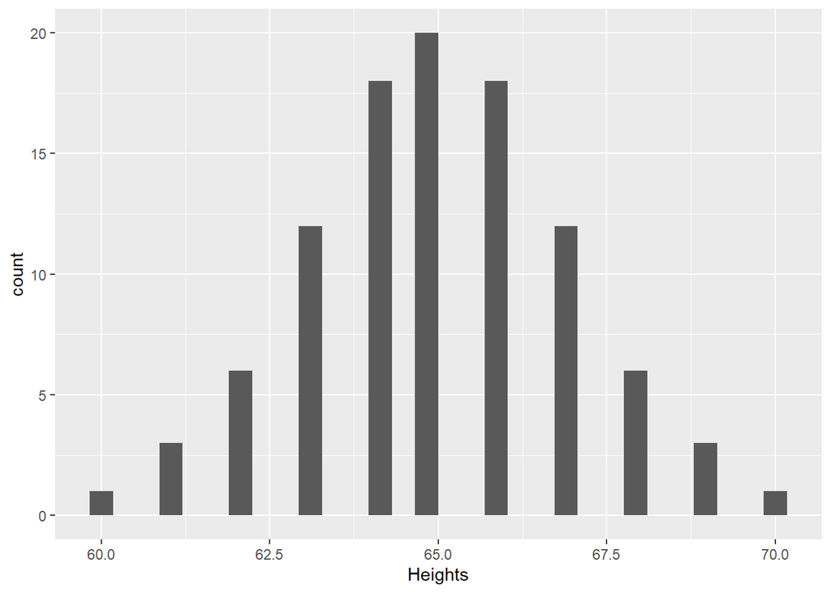

```r
ggplot(heights_table, aes(x=Heights)) + geom_histogram()
```

2. Interpret and describe the distribution. What’s the shape? Is there any skew?

**Answer:** The distribution is a bell curve and there is no skew.

3. Now lets add another layer to our histogram plot, facet_wrap().

3a. In the following code block, replace the `...` with the histogram code from above. Remember to uncomment the code if necessary.

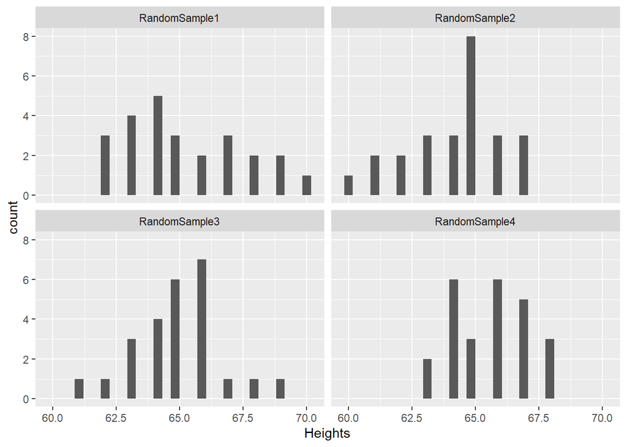

```r
ggplot(heights_table, aes(x=Heights)) + geom_histogram() + facet_wrap(~RandomSample)
```

3b. What does facet_wrap() do?

**Answer**: It creates separate panels for each group in a column.

3c. What is the relationship between the smaller histogram and the first large histogram?

**Answer:** The smaller histograms are subsets of the larger histogram.

4. Describe the differences you see between the 4 histograms. Specifically, describe differences in shape/skew and width.

**Answer:** Some are wider than others, some are skewed left whereas others are skewed left.

5. Why might the very fine details of a histogram, like jaggedness or small differences in skew/width, NOT be worth interpreting in a case study? *Hint:* The keyword here is “random”.

**Answer:** Because each histogram is a random sample of the true distribution, they may not be representative of the true distribution. So small details can just be random flukes and not meaningful.

6. Can you draw definitive conclusions about the *true mean* (in the first histogram) based on any given RandomSample histogram? Why or why not?

**Answer:** No. Because the random sample is *random*, we do not know if they are the same as the true mean without additional tests.

## Part 3: Transforming the histogram

In part 3, we will transform Heights so it has a mean of 0 and an SD of 1.

### A. Shift the entire histogram left to have a mean at 0.

1. Take a look at the first histogram. What is the mean of the Heights?

**Answer:** 65

2. In order to shift all the data points of Heights down a constant value, what operation do you need to do to the data? Addition, subtraction, multiplication, or division?

**Answer:** Subtraction

3. For the mean to be at 0, what constant value do you need to use?

**Answer:** 65

4. In the following code chunk, shift the data to the left to have a mean of 0. Replace the `...` with the mathematical operation that uses `Heights` and the constant value you identified.

```r
heights_table <- heights_table %>% mutate(ShiftedHeights = Heights - 65)
```

5. Use the `head()` to take a look at heights_table. What does the `mutate()` function do?

**Answer**: Adds another column.

6. Plot the ShiftedHeights as a histogram

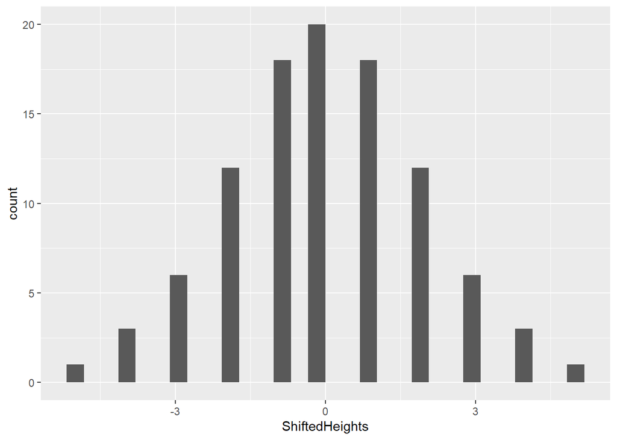

```r
ggplot(heights_table, aes(x=ShiftedHeights)) + geom_histogram()
```

### B. Make the histogram narrower to have an SD of 1.

7. In order to narrow the ShiftedHeights histogram by a constant factor, what operation do you need to do to the data? Addition, subtraction, multiplication, or division?

*Hint*: What’s an operation that makes both positive and negative numbers closer to zero without changing their sign?

**Answer:** Division

8. The SD of the histogram is 2. What constant factor should you use to reduce the SD of histogram from 2 to 1?

**Answer:** 2

9. In the following code chunk, make the data narrower to have an SD of 1. Replace the `...` with the mathematical expression that uses the variables ShiftedHeights and the constant factor you identified.

```r
heights_table <- heights_table %>% mutate(TransformedHeights = ShiftedHeights / 2)
```

10. Plot TransformedHeights as a histogram

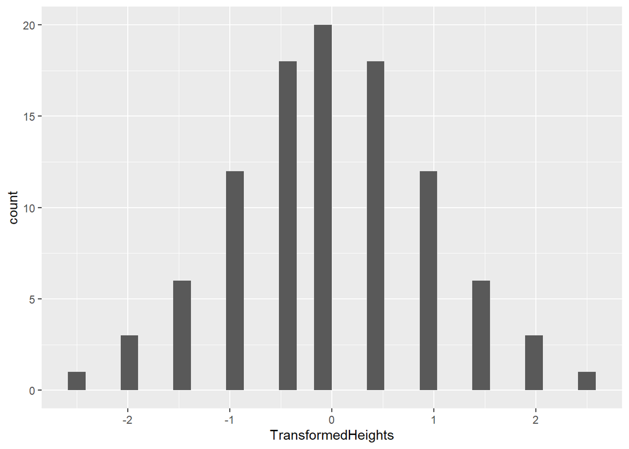

```r
ggplot(heights_table, aes(x=TransformedHeights)) + geom_histogram()
```

11. In A and B, we transformed Heights to have a mean of 0 and a SD of 1. There is a name for this particular transformation. What is the name for this score?

*Hint:* You should have learned about this from the online modules.

**Answer:** z-score

12. Write the full equation for this score using the following variables: `mean`, `SD`, and `x` (the value of each data point). Make sure to use parentheses properly!

**Answer:** (x - mean) / SD

13. Once you have completed all steps and checked your answers, knit the file and submit your html file output to Canvas.